# **DS220 – Project #2 on Data Analysis with Python**

*Background*:

Liverpool FC is an English soccer team that has been historically successful in many regards. They are one of the most decorated clubs around the world, having won 6 European Championships (Champions League), which puts them as the third most successful team in the competition. Domestically, they have won 19 league titles, one behind Manchester United, their bitter rivals. They are one of the most followed teams globally. With an estimated 500 million fans worldwide, it has a claim for one of the biggest fanbases in the soccer world. The fans are very passionate, with the English team being known for their relentless support in both good and bad times, recalling their renowned anthem, "You'll Never Walk Alone". Needless to say, Liverpool are one the best clubs in soccer history; however, it is important to state that most of the team's accolades were won almost 50 years ago, with their golden age being around the 70's and 80's. Since then, they have gone through many ups and downs, but mainly downs. They failed to win a domestic league in 30 years, one of their longest title droughts. In this time, they were also failing to classify to Europe's top competition, the Champions League.

*Recent times:*

So, how can Liverpool go back to where they belong? How can Liverpool go back to the top of the footballing world? Well, in 2015 a big change was made. Jurgen Klopp was appointed as manager, and as he stated when he signed, he wanted to rebuild the club. Klopp said: “You have to change from a doubter to a believer. We have to start together new.” From then, Klopp fulfilled his promise. They ended their league drought in 2020, winning their first league title since 1990. They also won the most cherished trophy in world football, the Champions League, in 2019. Jurgen Klopp set back the standards for Liverpool, but there is still a long way to go for them to be considered the feared giants that they once were. So, with the basis for a successful team already established, what can they do to go back to the very top?

# Database:

FiveThirtyEight's "Global Club Soccer Rankings" database will be very helpful to try to improve Liverpool FC and find solutions to make them a better team.

### How does the database work?

The database has 641 rows, which means there is information about 641 different teams. There are also 7 columns: ranking (rank), previous ranking (prev_rank), name of the team (name), league in which the team plays (league), an offense statistic (off), a defense statistic (def), and most importantly, a rating system originally devised by FiveThirtyEight's editor-in-chief Nate Silver in for rating international soccer teams. This rating is called Soccer Power Index (SPI). The SPI is a system that estimates a team's overall strength. "In our system, every team has an offensive rating that represents the number of goals it would be expected to score against an average team on a neutral field, and a defensive rating that represents the number of goals it would be expected to concede. These ratings, in turn, produce an overall SPI rating, which represents the percentage of available points — a win is worth 3 points, a tie worth 1 point, and a loss worth 0 points — the team would be expected to take if that match were played over and over again" (Boyce, 2020). To read more how these ratings are performed, you can visit the following link: https://fivethirtyeight.com/methodology/how-our-club-soccer-predictions-work/

```python
from datascience import *
import numpy as np

import matplotlib
matplotlib.use('Agg')
%matplotlib inline
import matplotlib.pyplot as plots
plots.style.use('fivethirtyeight')

# blue and red markers by default
Table.chart_colors = ('blue', 'red') + Table.chart_colors
# white background by default
plots.rcParams['figure.facecolor']='white'
plots.rcParams['axes.facecolor']='white'

import pandas as pd
```

# Questions and Solutions

To start, we are going to initialize the database into a table called 'teams'. We are also going to select every column except for previous ranking, as it is mostly very repetitive with the ranking column.

```python
teams = Table.read_table('spi_global_rankings.csv')
teams = teams.select('rank', 'name', 'league', 'off', 'def', 'spi')
teams
```

| rank | name | league | off | def | spi |
| --- | --- | --- | --- | --- | --- |
| 1 | Manchester City | Barclays Premier League | 2.79 | 0.28 | 92 |
| 2 | Bayern Munich | German Bundesliga | 3.04 | 0.68 | 87.66 |
| 3 | Barcelona | Spanish Primera Division | 2.45 | 0.43 | 86.4 |
| 4 | Real Madrid | Spanish Primera Division | 2.56 | 0.6 | 84.41 |
| 5 | Liverpool | Barclays Premier League | 2.63 | 0.67 | 83.93 |
| 6 | Arsenal | Barclays Premier League | 2.53 | 0.61 | 83.92 |
| 7 | Newcastle | Barclays Premier League | 2.38 | 0.53 | 83.7 |
| 8 | Napoli | Italy Serie A | 2.3 | 0.51 | 83.25 |
| 9 | Borussia Dortmund | German Bundesliga | 2.83 | 0.84 | 82.91 |
| 10 | Brighton and Hove Albion | Barclays Premier League | 2.47 | 0.73 | 80.88 |

... (631 rows omitted)

Where does Liverpool rank in the SPI rankings for all teams? Where do they rank in their domestic league?

```python
liverpool_globally = teams.where('name', are.equal_to('Liverpool'))
liverpool_globally
```

| rank | name | league | off | def | spi |
| --- | --- | --- | --- | --- | --- |
| 5 | Liverpool | Barclays Premier League | 2.63 | 0.67 | 83.93 |

```python
english_teams = teams.where('league', are.equal_to('Barclays Premier League'))
english_teams['rank'] = np.arange(1,(english_teams.num_rows+1))
english_teams.where('name', are.equal_to('Liverpool'))
```

| rank | name | league | off | def | spi |
| --- | --- | --- | --- | --- | --- |
| 2 | Liverpool | Barclays Premier League | 2.63 | 0.67 | 83.93 |

To find where Liverpool ranks globally, I used the teams table that contains every row and found the instance where the column 'name' was equal to 'Liverpool'. We found that Liverpool is ranked number 5 globally, which is pretty good, but not as high as it is wanted. To find where Liverpool ranks among teams in their league, we first created a new table that contains only teams where the league is the 'Barclays Premier League', which is the English league. Then, we updated the 'rank' values so that the ranking was regarding the position in this new table. We found that currently Liverpool is second in the English league, which is very close to where they should be considering their history, number 1. With this problem, we find that Liverpool is close to achieving their goal and becoming a top 3 team in the world. To do this, first they need to become the best in their league.

Okay, so now we know that Liverpool is in a good position, but how do they go up from there? First, let's see how the offense statistics affect the SPI of teams.

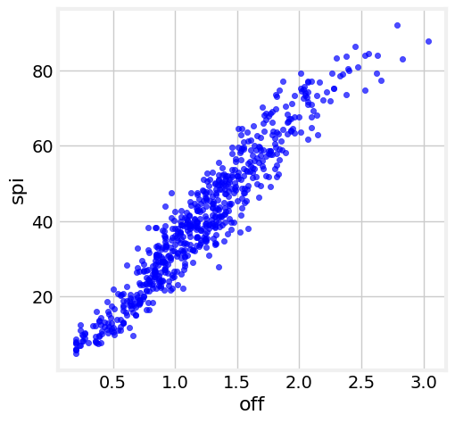

```python
teams.scatter('off', 'spi')
```

We can see that there is a positive correlation between offense and SPI. Teams that have a higher offense statistic tend to have a higher SPI.

Now, let's see the correlation between the defense statistic and the SPI ranking.

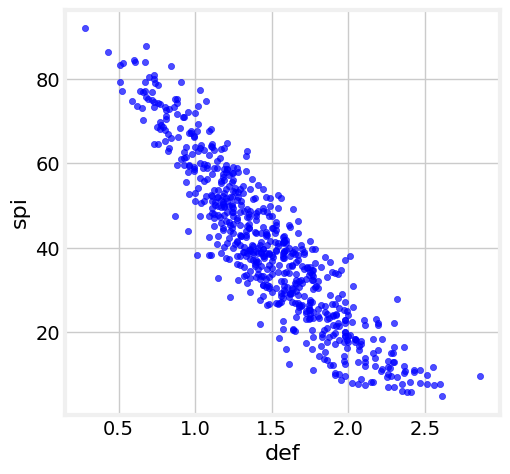

```python
teams.scatter('def', 'spi')
```

Using a scatter plot, we see that the correlation between defense and SPI is negative. This means that teams that have a higher defense statistic tend to have a lower SPI.

Now we know that for Liverpool to improve, they should focus on improving their offense statistic, which means find ways to score more goals, and decrease their defense statistic, which means that they should find ways to concede less goals. We want to compare Liverpool to teams that are near their level, but first, we want to find some more information regarding the defense and offense statistics.

Let's see if the data is consistent. Are teams that have a better offense always better than teams that have a lower offense? Are teams that have a lower defense always better than teams that have a higher defense?

```python
spi = teams.column('spi')
average_spi = np.average(spi)
average_spi

upper_half  = (teams.column('spi') >= average_spi) == True


teams = teams.with_columns('Better than average?', upper_half)
```

What we have done so far is found the average SPI of all teams. Then, we created a new column that states True if the team's SPI is higher than average.

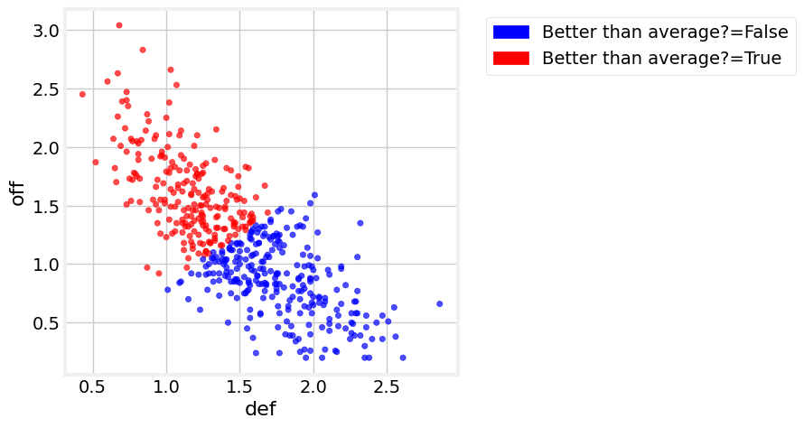

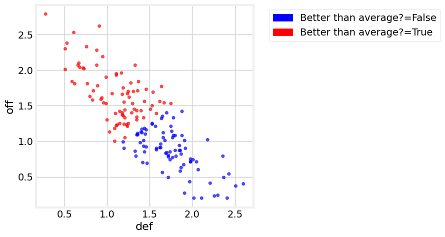

```python
shuffled = teams.shuffle()


train_set = shuffled.take(np.arange(0,int(shuffled.num_rows * 0.75)))
test_set = shuffled.take(np.arange(int(shuffled.num_rows * 0.75), shuffled.num_rows))

train_set.scatter('def', 'off', group = 'Better than average?')
test_set.scatter('def', 'off', group = 'Better than average?')
```

To reliably evaluate the accuracy of a data-driven predictor, we must always split our data into a training set and a test set. That is what is being done here. First, the data is shuffled, and then, we take 75% of teams as the training set and the rest as the test set. We scatter the teams by offense and defense statistics, dividing by seeing the teams better than average in red, and the teams worse than average in blue. With these scatter plots, we can see that the data is very consistent. Teams with a lower defense and a higher offense are clustered in the upper left corner, and we see that all of these teams are better than average. The rest are in the lower right corner, indicating a higher defense stat and a lower attacking stat. So yes, the data is consistent.

Now, let's see how Liverpool's attack compares to the top 20 teams. Does a better attack means that the team is immediately better? In other words, should Liverpool focus on using all their resources to improve their attack and neglect their defense?

```python
top20 = teams.take(np.arange(20))
top20offense = top20.sort('off', descending = True)
top20offense = top20offense.with_columns('Offense Ranking', np.arange(1,21))
top20offense.show()
```

| rank | name | league | off | def | spi | Better than average? | Offense Ranking |
| --- | --- | --- | --- | --- | --- | --- | --- |
| 2 | Bayern Munich | German Bundesliga | 3.04 | 0.68 | 87.66 | True | 1 |
| 9 | Borussia Dortmund | German Bundesliga | 2.83 | 0.84 | 82.91 | True | 2 |
| 1 | Manchester City | Barclays Premier League | 2.79 | 0.28 | 92 | True | 3 |
| 18 | Ajax | Dutch Eredivisie | 2.66 | 1.03 | 77.36 | True | 4 |
| 5 | Liverpool | Barclays Premier League | 2.63 | 0.67 | 83.93 | True | 5 |
| 15 | Paris Saint-Germain | French Ligue 1 | 2.62 | 0.91 | 79.12 | True | 6 |
| 4 | Real Madrid | Spanish Primera Division | 2.56 | 0.6 | 84.41 | True | 7 |
| 6 | Arsenal | Barclays Premier League | 2.53 | 0.61 | 83.92 | True | 8 |
| 10 | Brighton and Hove Albion | Barclays Premier League | 2.47 | 0.73 | 80.88 | True | 9 |
| 3 | Barcelona | Spanish Primera Division | 2.45 | 0.43 | 86.4 | True | 10 |
| 12 | Benfica | Portuguese Liga | 2.4 | 0.73 | 79.96 | True | 11 |
| 11 | RB Leipzig | German Bundesliga | 2.39 | 0.7 | 80.42 | True | 12 |
| 7 | Newcastle | Barclays Premier League | 2.38 | 0.53 | 83.7 | True | 13 |
| 16 | Manchester United | Barclays Premier League | 2.35 | 0.74 | 79.08 | True | 14 |
| 17 | Internazionale | Italy Serie A | 2.33 | 0.76 | 78.43 | True | 15 |
| 8 | Napoli | Italy Serie A | 2.3 | 0.51 | 83.25 | True | 16 |
| 14 | Atletico Madrid | Spanish Primera Division | 2.26 | 0.67 | 79.29 | True | 17 |
| 20 | Brentford | Barclays Premier League | 2.1 | 0.67 | 77.14 | True | 18 |
| 19 | Lille | French Ligue 1 | 2.07 | 0.64 | 77.2 | True | 19 |
| 13 | Aston Villa | Barclays Premier League | 2.01 | 0.51 | 79.3 | True | 20 |

Here we can see some interesting things. First, we can see that offense is very important, as the top 2 teams (Bayern Munich and Manchester City) are in the top 3 rankings of offense, but we also see that teams that are not necessarily ranked that high, like Ajax (at 18 overall but at 4 in offense rankings), who are in higher rankings than teams that are ranked very high overall, like Barcelona. We can also see that the rankings are shuffled quite a lot, meaning that offense may not necessarily be that decisive regarding overall SPI.

To clarify a bit more, let's ask the same question, but regarding defense.

Does a lower defense means that the team is immediately better? In other words, should Liverpool focus on using all their resources to improve their defense and neglect their attack?

```python
top20defense = top20.sort('def')
top20defense = top20defense.with_columns('Defense Ranking', np.arange(1,21))
top20defense.show()
```

| rank | name | league | off | def | spi | Better than average? | Defense Ranking |
| --- | --- | --- | --- | --- | --- | --- | --- |
| 1 | Manchester City | Barclays Premier League | 2.79 | 0.28 | 92 | True | 1 |
| 3 | Barcelona | Spanish Primera Division | 2.45 | 0.43 | 86.4 | True | 2 |
| 8 | Napoli | Italy Serie A | 2.3 | 0.51 | 83.25 | True | 3 |
| 13 | Aston Villa | Barclays Premier League | 2.01 | 0.51 | 79.3 | True | 4 |
| 7 | Newcastle | Barclays Premier League | 2.38 | 0.53 | 83.7 | True | 5 |
| 4 | Real Madrid | Spanish Primera Division | 2.56 | 0.6 | 84.41 | True | 6 |
| 6 | Arsenal | Barclays Premier League | 2.53 | 0.61 | 83.92 | True | 7 |
| 19 | Lille | French Ligue 1 | 2.07 | 0.64 | 77.2 | True | 8 |
| 5 | Liverpool | Barclays Premier League | 2.63 | 0.67 | 83.93 | True | 9 |
| 14 | Atletico Madrid | Spanish Primera Division | 2.26 | 0.67 | 79.29 | True | 10 |
| 20 | Brentford | Barclays Premier League | 2.1 | 0.67 | 77.14 | True | 11 |
| 2 | Bayern Munich | German Bundesliga | 3.04 | 0.68 | 87.66 | True | 12 |
| 11 | RB Leipzig | German Bundesliga | 2.39 | 0.7 | 80.42 | True | 13 |
| 10 | Brighton and Hove Albion | Barclays Premier League | 2.47 | 0.73 | 80.88 | True | 14 |
| 12 | Benfica | Portuguese Liga | 2.4 | 0.73 | 79.96 | True | 15 |
| 16 | Manchester United | Barclays Premier League | 2.35 | 0.74 | 79.08 | True | 16 |
| 17 | Internazionale | Italy Serie A | 2.33 | 0.76 | 78.43 | True | 17 |
| 9 | Borussia Dortmund | German Bundesliga | 2.83 | 0.84 | 82.91 | True | 18 |
| 15 | Paris Saint-Germain | French Ligue 1 | 2.62 | 0.91 | 79.12 | True | 19 |
| 18 | Ajax | Dutch Eredivisie | 2.66 | 1.03 | 77.36 | True | 20 |

How many teams' overall rank is equal to their defense and offense ranking? What occurs more often, a defense ranking being the same as actual ranking or an offense ranking being the same as actual ranking? In other words, is one of them more essential for overall SPI than the other?

```python
defense_agrees = sum(top20defense['rank'] == top20defense['Defense Ranking'])
offense_agrees = sum(top20offense['rank'] == top20offense['Offense Ranking'])
print('A team has the same defense ranking and overall ranking', defense_agrees, ' times.')
print('A team has the same offense ranking and overall ranking', offense_agrees, ' times.')
```

```
A team has the same defense ranking and overall ranking 3  times.
A team has the same offense ranking and overall ranking 2  times.
```

```python
moreoften = max(defense_agrees, offense_agrees)
if moreoften == defense_agrees:
  print('Defense and SPI agreements occur more often that offense and SPI agreements')
else:
    print('Offense and SPI agreements occur more often that defense and SPI agreements')
```

```
Defense and SPI agreements occur more often that offense and SPI agreements
```